# TODD_Skills_Test_3

2025-12-12

### Library

```r
library(tidyverse)
library(broom)
```

## Faculty Saleries

This is an anylization of the ‘FacultySalaries_1995.csv’ dataset.

### Cleaned data

to clean this data it needed to be pivited longer. This was done by first renaming the columns like ‘AvgFullProfSalary’ to simply ‘Full’ for the three ranks. This was then pivited longer so the ranks were in a column named ‘Rank’ with their saleries in a column named ‘Salary’.

```r
fac = read.csv('FacultySalaries_1995.csv')

fac_name = fac %>%
  rename(Full = AvgFullProfSalary,
         Assoc = AvgAssocProfSalary,
         Assist = AvgAssistProfSalary)

fac_long = fac_name %>%
  pivot_longer(cols = c(Full, Assoc, Assist),
               names_to = "Rank",
               values_to = "Salary")
```

### Copied graph

Becasue this data was cleaned in this way it made it possible for the Salaries to be a consistent Y variable for all the ranks and be graphed like so:

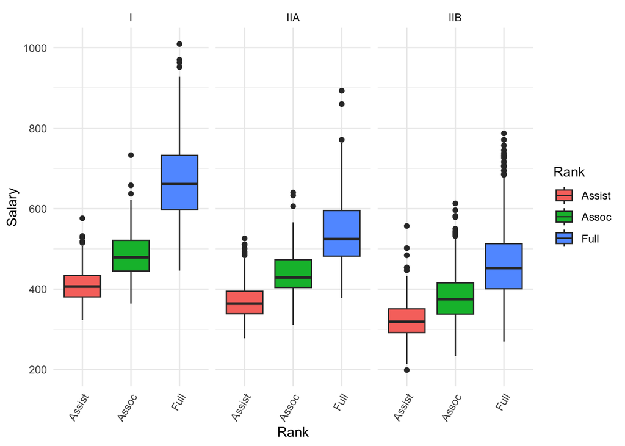

```r
fac_long %>%
  filter(Tier != 'VIIB') %>%
  ggplot(aes(x = Rank,
             y = Salary,
             fill = Rank)) +
  geom_boxplot() +
  facet_wrap(~ Tier) +
  theme_minimal() +
  theme(axis.text.x = element_text(angle = 60, hjust = 1))
```

### ANOVA model

This is an ANOVA model displaying the influences the state tier and rank had on professors salary.

```r
mod = lm(data = fac_long,
         Salary ~ State + Tier + Rank)

summary(mod)
```

```
##
## Call:
## lm(formula = Salary ~ State + Tier + Rank, data = fac_long)
##
## Residuals:
##     Min      1Q  Median      3Q     Max
## -206.44  -36.28   -2.12   31.86  329.50
##
## Coefficients: (1 not defined because of singularities)
##             Estimate Std. Error t value Pr(>|t|)
## (Intercept)  474.859     17.609  26.967  < 2e-16 ***
## StateAL      -70.503     18.993  -3.712 0.000209 ***
## StateAR      -55.252     19.609  -2.818 0.004866 **
## StateAZ      -84.749     24.666  -3.436 0.000598 ***
## StateCA       22.566     18.052   1.250 0.211369
## StateCO      -40.961     19.641  -2.085 0.037102 *
## StateCT       37.744     19.509   1.935 0.053110 .
## StateDC       -9.247     21.064  -0.439 0.660697
## StateDE      -17.945     25.171  -0.713 0.475947
## StateFL      -39.752     19.148  -2.076 0.037969 *
## StateGA      -38.424     18.993  -2.023 0.043144 *
## StateHI       35.450     27.542   1.287 0.198135
## StateIA      -36.256     18.789  -1.930 0.053736 .
## StateID      -87.703     23.351  -3.756 0.000176 ***
## StateIL      -31.318     18.141  -1.726 0.084384 .
## StateIN      -44.314     18.296  -2.422 0.015488 *
## StateKS     -103.211     19.289  -5.351 9.35e-08 ***
## StateKY      -68.865     18.983  -3.628 0.000290 ***
## StateLA      -65.740     19.093  -3.443 0.000582 ***
## StateMA       33.907     18.223   1.861 0.062888 .
## StateMD       -9.555     18.970  -0.504 0.614505
## StateME      -24.474     19.876  -1.231 0.218301
## StateMI      -21.459     18.540  -1.157 0.247180
## StateMN      -18.854     18.765  -1.005 0.315114
## StateMO      -61.568     18.480  -3.332 0.000873 ***
## StateMS     -101.576     20.040  -5.069 4.23e-07 ***
## StateMT     -119.917     21.314  -5.626 2.00e-08 ***
## StateNC      -46.821     18.274  -2.562 0.010446 *
## StateND      -84.897     22.736  -3.734 0.000192 ***
## StateNE      -56.408     19.476  -2.896 0.003801 **
```

[output cut: 19 more lines]

```
## StateWV      -79.629     19.634  -4.056 5.11e-05 ***
## StateWW     -194.717     38.979  -4.995 6.18e-07 ***
## StateWY     -112.050     38.979  -2.875 0.004071 **
## TierIIA      -79.331      3.258 -24.350  < 2e-16 ***
## TierIIB     -131.870      3.096 -42.590  < 2e-16 ***
## TierVIIB          NA         NA      NA       NA
## RankAssoc     63.840      2.536  25.178  < 2e-16 ***
## RankFull     170.733      2.554  66.838  < 2e-16 ***
## ---
## Signif. codes:  0 '***' 0.001 '**' 0.01 '*' 0.05 '.' 0.1 ' ' 1
##
## Residual standard error: 60.29 on 3299 degrees of freedom
##   (128 observations deleted due to missingness)
## Multiple R-squared:  0.7095, Adjusted R-squared:  0.7047
## F-statistic: 146.5 on 55 and 3299 DF,  p-value: < 2.2e-16
```

## Esencial oils and time

This ia an analyzation of the data set ‘Juniper_Oils.csv’.

### Cleaned data

To clean this data the many different columns of chemicals and their concentrations needed to be pivoted longer. The chemical names are in a column named ‘ChemicalID’ and the concentrations are in a column named ‘Concentrations’.

```r
jun = read.csv('Juniper_Oils.csv')

jun_long = jun %>%
  pivot_longer(cols = c("alpha.pinene","para.cymene","alpha.terpineol",
                        "cedr.9.ene","alpha.cedrene","beta.cedrene",
                        "cis.thujopsene","alpha.himachalene","beta.chamigrene",
                        "cuparene","compound.1","alpha.chamigrene","widdrol",
                        "cedrol","beta.acorenol","alpha.acorenol",
                        "gamma.eudesmol","beta.eudesmol","alpha.eudesmol",
                        "cedr.8.en.13.ol","cedr.8.en.15.ol","compound.2",
                        "thujopsenal"),
               names_to = 'ChemicalID',
               values_to = 'Concentration')
```

### Comparison of chemicals

This is a comparison of the effect that time has on decomposing chemicals in a juniper after a fire. You can compare each chemical to one another because this graph is facet warped by chemical ID.

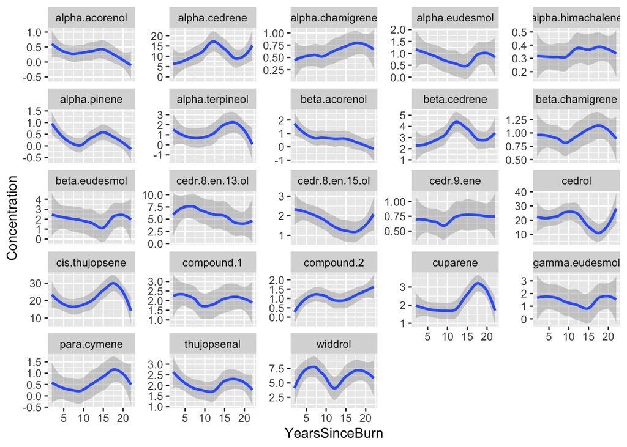

```r
jun_long %>%
  ggplot(aes(x = YearsSinceBurn,
             y = Concentration)) +
  geom_smooth() +
  facet_wrap(~ ChemicalID, scales = "free_y")
```

### Tidy table

This is a table showing the statistical significance that time after fire had on each chemical in a juniper.

```r
mod2 = jun_long %>%
  group_by(ChemicalID) %>%
  do(tidy(glm(Concentration ~ YearsSinceBurn, data = ., family = gaussian()))) %>%
  ungroup()

mod3 = mod2 %>%
  filter(term == "YearsSinceBurn")

mod3
```

```
## # A tibble: 23 × 6
##    ChemicalID        term           estimate std.error statistic p.value
##    <chr>             <chr>             <dbl>     <dbl>     <dbl>   <dbl>
##  1 alpha.acorenol    YearsSinceBurn -0.0223    0.0115     -1.94  0.0610
##  2 alpha.cedrene     YearsSinceBurn  0.204     0.212       0.962 0.343
##  3 alpha.chamigrene  YearsSinceBurn  0.0153    0.00953     1.61  0.118
##  4 alpha.eudesmol    YearsSinceBurn -0.00311   0.0213     -0.146 0.885
##  5 alpha.himachalene YearsSinceBurn  0.00335   0.00423     0.792 0.434
##  6 alpha.pinene      YearsSinceBurn -0.0244    0.0138     -1.77  0.0869
##  7 alpha.terpineol   YearsSinceBurn  0.0195    0.0431      0.454 0.653
##  8 beta.acorenol     YearsSinceBurn -0.0655    0.0226     -2.90  0.00664
##  9 beta.cedrene      YearsSinceBurn  0.0320    0.0399      0.802 0.428
## 10 beta.chamigrene   YearsSinceBurn  0.00572   0.0103      0.555 0.583
## # ℹ 13 more rows
```

### Significant tidy table

This table shows only the chemicals that were effected significantly by time after fire.

```r
sig_mod = mod3 %>%
  filter(p.value < 0.05)

sig_mod
```

```
## # A tibble: 3 × 6
##   ChemicalID    term           estimate std.error statistic p.value
##   <chr>         <chr>             <dbl>     <dbl>     <dbl>   <dbl>
## 1 beta.acorenol YearsSinceBurn  -0.0655    0.0226     -2.90 0.00664
## 2 compound.2    YearsSinceBurn   0.0356    0.0173      2.06 0.0471
## 3 cuparene      YearsSinceBurn   0.0550    0.0244      2.26 0.0310
```